# Introducción a la programación y análisis de datos en R

Día 2 · Bloque 2 — arrange(), mutate(), case_when(), combinar y unir tablas

Filip Andras

CIMCYC — Universidad de Granada

16 octubre 2026

## Mapa del día 2

Bloque 1  
9:00 – 10:30

¿Qué es el tidyverse?

Datos tidy

El pipe `|>`

Ej. 1–2

Importar datos

Ej. 3

Los verbos de `dplyr`

Ej. 4–5

Bloque 2  
11:00 – 12:30

Ordenar filas

Ej. 6

Crear y transformar variables

Condicionales

Ej. 7–8

Combinar tablas

Joins

Ej. 9

Bloque 3  
13:00 – 14:00 · 60’

Agregar datos: `group_by()` + `summarise()`

Ej. 10

Pipelines completos

Guardar datos procesados

Pipeline de preprocesado

Ej. 11

## El paquete de este bloque: `dplyr`

[figure not shown]

[figure not shown]

[`readr`](https://rstudio.github.io/cheatsheets/html/data-import.html)Importar archivos (CSV, TSV, etc.)

[`ggplot2`](https://rstudio.github.io/cheatsheets/html/data-visualization.html)Visualización de datos (gráficos)

[`forcats`](https://rstudio.github.io/cheatsheets/html/factors.html)Trabajar con factores (variables categóricas)

[`tidyr`](https://rstudio.github.io/cheatsheets/html/tidyr.html)Reestructurar datos (pivotar, separar, unir)

[`tibble`](https://tibble.tidyverse.org/)Data frames mejorados

[`dplyr`](https://rstudio.github.io/cheatsheets/html/data-transformation.html)Manipulación de datos (filtrar, seleccionar, transformar)

[`stringr`](https://rstudio.github.io/cheatsheets/html/strings.html)Manipulación de texto

[`purrr`](https://rstudio.github.io/cheatsheets/html/purrr.html)Programación funcional (iteración)

Haz clic en `dplyr` para abrir su chuleta oficial (*cheatsheet*).

# Ordenar filas: `arrange()`

## `arrange()` — ordenar filas

Ordenar por ansiedad pre-tratamiento (ascendente, por defecto)

```r
datos_ordenados <- data_trial |>
  filter(group == "CBT") |>
  arrange(anxiety_pre)
head(datos_ordenados)
```

```
# A tibble: 6 x 16
  patient_id site_id group sex      age n_sessions anxiety_pre anxiety_post
       <dbl> <chr>   <chr> <chr>  <dbl>      <dbl>       <dbl>        <dbl>
1          8 site_01 CBT   female    32         15        10            5.9
2         44 site_01 CBT   male      26         14        10            4.4
3         68 site_01 CBT   male      60         13        10.6          3.9
4         65 site_01 CBT   male      48         17        11.6          6.1
5         16 site_03 CBT   male      59         15        11.7          8.2
6         43 site_01 CBT   female    45          6        11.7          8.3
# i 8 more variables: depression_pre <dbl>, depression_post <dbl>,
#   wellbeing_pre <dbl>, wellbeing_post <dbl>, ucla_pre <dbl>, ucla_post <dbl>,
#   rosenberg_pre <dbl>, rosenberg_post <dbl>
```

## `arrange()` — orden descendente

Orden descendente: mayor puntuación primero

```r
datos_desc <- data_trial |>
  filter(group == "CBT") |>
  arrange(desc(anxiety_pre))
head(datos_desc)
```

```
# A tibble: 6 x 16
  patient_id site_id group sex      age n_sessions anxiety_pre anxiety_post
       <dbl> <chr>   <chr> <chr>  <dbl>      <dbl>       <dbl>        <dbl>
1         58 site_03 CBT   female    29         11        20.6         15.7
2          1 site_01 CBT   male      42         11        20           16.6
3         90 site_03 CBT   female    31         11        19.9         15.2
4         71 site_02 CBT   female    47         14        19.8         15.4
5        100 site_01 CBT   male      30         13        19.4         14.6
6         21 site_03 CBT   male      39         15        18.6         16.6
# i 8 more variables: depression_pre <dbl>, depression_post <dbl>,
#   wellbeing_pre <dbl>, wellbeing_post <dbl>, ucla_pre <dbl>, ucla_post <dbl>,
#   rosenberg_pre <dbl>, rosenberg_post <dbl>
```

`desc()` invierte el orden: de mayor a menor.

## Ejercicio 6 — ordenar pacientes

Tiempo: 5 minutos

1. Ordena `data_trial` por `wellbeing_pre` de **mayor a menor**.
2. Muestra solo las columnas `patient_id`, `group`, `wellbeing_pre`.
3. ¿Qué paciente tiene el bienestar más alto?
4. Guarda el resultado en un objeto.

# Crear y transformar variables: `mutate()`

## `mutate()` — transformar y crear variables

`mutate()` es uno de los verbos **más importantes** de dplyr. Permite:

- **Crear** nuevas columnas a partir de las existentes
- **Modificar** columnas existentes (sobrescribirlas)
- **Clasificar** datos con `if_else()` (2 categorías) o `case_when()` (varias)
- Combinar con `select()` para ver solo las columnas relevantes

## `mutate()` — crear nuevas columnas

Crear una variable nueva: el cambio en la puntuación de ansiedad

```r
datos_cambio <- data_trial |>
  mutate(anxiety_change = anxiety_post - anxiety_pre) |>
  select(patient_id,
         group,
         anxiety_pre,
         anxiety_post,
         anxiety_change)
head(datos_cambio)
```

```
# A tibble: 6 x 5
  patient_id group anxiety_pre anxiety_post anxiety_change
       <dbl> <chr>       <dbl>        <dbl>          <dbl>
1          1 CBT          20           16.6           -3.4
2          2 CBT          17.7         12.3           -5.4
3          3 CBT          15.5         11             -4.5
4          4 CBT          15.9         11.4           -4.5
5          5 CBT          12.7          9.1           -3.6
6          6 CBT          14.3          8.4           -5.9
```

¿Recuerdas cómo lo hicimos el primer día en R base?

## `mutate()` — modificar columnas existentes

```r
datos_redondeados <- data_trial |>
  mutate(age_rounded = round(age, -1)) |>  # -1 redondea a decenas
  select(patient_id,
         age,
         age_rounded)
head(datos_redondeados)
```

```
# A tibble: 6 x 3
  patient_id   age age_rounded
       <dbl> <dbl>       <dbl>
1          1    42          40
2          2    23          20
3          3    56          60
4          4    39          40
5          5    36          40
6          6    27          30
```

Si usas el **mismo nombre** de columna, `mutate()` la sobrescribe.

# Crear variables con condicionales

## `if_else()` — estructura

La estructura es siempre:

if_else(condicion, valor_si_TRUE, valor_si_FALSE)

Es la misma idea que la función **SI** de Excel: `=SI(prueba_lógica; valor_si_verdadero; valor_si_falso)` (en Excel en inglés, `=IF()`)

- Si la condición se cumple → devuelve el segundo argumento
- Si no se cumple → devuelve el tercer argumento
- Se puede combinar con operadores: `&`, `|`, `>=`, `<=`, `==`, `!=`

## `if_else()` — dos categorías

Variable binaria: ansiedad alta vs. baja

```r
datos_ansiedad <- data_trial |>
  mutate(ansiedad_alta = if_else(
    anxiety_pre >= 15, "grave", "moderada_o_leve"
  )) |>
  select(patient_id,
         anxiety_pre,
         ansiedad_alta)
head(datos_ansiedad)
```

```
# A tibble: 6 x 3
  patient_id anxiety_pre ansiedad_alta
       <dbl>       <dbl> <chr>
1          1        20   grave
2          2        17.7 grave
3          3        15.5 grave
4          4        15.9 grave
5          5        12.7 moderada_o_leve
6          6        14.3 moderada_o_leve
```

## Ejercicio 7 — `if_else()`

Tiempo: 5 minutos

Usa `if_else()` para crear una nueva columna `grupo_edad` en `data_trial`:

- Si `age >= 60` → `"senior"`
- Si no → `"junior"`

Después, cuenta cuántos pacientes hay en cada categoría con `count()`.

## `case_when()` — estructura

case_when(

condicion_1 ~ "resultado_1",

condicion_2 ~ "resultado_2",

condicion_3 ~ "resultado_3",

.default = "resultado_por_defecto"

)

## `case_when()` — se evalúa en orden

Cada valor baja por las condiciones **de arriba abajo** y se queda con la primera que es `TRUE`:

`anxiety_pre`

2

7

12

18

`anxiety_pre <= 4 ~ "minima"`

TRUE

FALSE

FALSE

FALSE

`anxiety_pre <= 9 ~ "leve"`

TRUE

FALSE

FALSE

`anxiety_pre <= 14 ~ "moderada"`

TRUE

FALSE

`.default = "grave"`

resto

resultado

"minima"

"leve"

"moderada"

"grave"

`TRUE` en naranja: se asigna ese resultado y ya no se mira nada más · `FALSE`: pasa a la línea siguiente · casilla vacía: esa condición ya no se evalúa

**Importante**

Las condiciones se evalúan **en orden**. La primera que se cumple “gana”. Por eso no necesitamos escribir `>= 5 & <= 9` — si llega a la segunda línea, ya sabemos que `> 4`.

## `case_when()` — múltiples categorías

¿Y si queremos más de dos categorías?

Clasificar la gravedad según la escala de ansiedad GAD-7 (0-21)

```r
datos_gravedad <- data_trial |>
  mutate(gravedad_ansiedad = case_when(
    anxiety_pre <= 4  ~ "minima",
    anxiety_pre <= 9  ~ "leve",
    anxiety_pre <= 14 ~ "moderada",
    .default          = "grave"
  )) |>
  select(patient_id,
         anxiety_pre,
         gravedad_ansiedad)
head(datos_gravedad)
```

## `case_when()` — múltiples categorías

```
# A tibble: 6 x 3
  patient_id anxiety_pre gravedad_ansiedad
       <dbl>       <dbl> <chr>
1          1        20   grave
2          2        17.7 grave
3          3        15.5 grave
4          4        15.9 grave
5          5        12.7 moderada
6          6        14.3 grave
```

## Ejercicio 8 — clasificar la gravedad de la depresión

Tiempo: 7 minutos

Crea una columna `gravedad_depresion` en `data_trial` usando `case_when()` basada en `depression_pre` (PHQ-9, rango 0-27):

- `<= 4` → `"minima"`
- `<= 9` → `"leve"`
- `<= 14` → `"moderada"`
- `<= 19` → `"moderadamente_grave"`
- resto → `"grave"`

Guarda el resultado y usa `count()` para ver cuántos pacientes hay en cada categoría.

## Errores comunes — case_when() (1/2)

```r
# error 1: olvidar .default --- deja NAs en filas que no coinciden
data_trial |>
  mutate(nivel = case_when(
    anxiety_pre <= 4 ~ "minima",
    anxiety_pre <= 9 ~ "leve"
  )) |>
  count(nivel)
```

```
# A tibble: 1 x 2
  nivel     n
  <chr> <int>
1 <NA>    300
```

## Errores comunes — case_when() (2/2)

```r
# error 2: orden de condiciones erroneo (primera que coincide gana)
data_trial |>
  mutate(nivel = case_when(
    anxiety_pre <= 14 ~ "moderada",
    anxiety_pre <= 4  ~ "minima",   # nunca se alcanza
    .default          = "grave"
  )) |>
  count(nivel)
```

```
# A tibble: 2 x 2
  nivel        n
  <chr>    <int>
1 grave      231
2 moderada    69
```

**Solución:** ordena las condiciones de **más restrictiva a menos restrictiva**, y usa `.default` para capturar el resto.

# Combinar tablas

## `bind_rows()` — apilar filas

Cuando tenemos dos tablas con las **mismas columnas** y queremos unirlas verticalmente:

Ejemplo: notas de dos clases distintas

```r
clase_A <- tibble(
  alumno = c("Ana", "Ben", "Carlos"),
  nota   = c(85, 92, 78)
)
clase_B <- tibble(
  alumno = c("Diana", "Eva"),
  nota   = c(90, 88)
)
# apilar verticalmente
todas_las_notas <-
  bind_rows(clase_A, clase_B)
todas_las_notas
```

```
# A tibble: 5 x 2
  alumno  nota
  <chr>  <dbl>
1 Ana       85
2 Ben       92
3 Carlos    78
4 Diana     90
5 Eva       88
```

## `bind_cols()` — pegar columnas

Cuando tenemos dos tablas con el **mismo número de filas** y queremos unirlas horizontalmente:

Pegar lado a lado (¡mismo número de filas!)

```r
nombres <- tibble(
  alumno = c("Ana", "Ben", "Carlos")
)
notas <- tibble(
  nota = c(85, 92, 78)
)
datos_pegados <-
  bind_cols(nombres, notas)
datos_pegados
```

```
# A tibble: 3 x 2
  alumno  nota
  <chr>  <dbl>
1 Ana       85
2 Ben       92
3 Carlos    78
```

**Cuidado**

`bind_cols()` sí comprueba que las dos tablas tengan el **mismo número de filas** (si no, da error), pero **no** comprueba que cada fila sea la misma persona: pega por posición. Úsalo solo cuando estés seguro de que el orden es correcto.

# Joins

## ¿Por qué necesitamos joins?

Los datos a menudo vienen en **tablas separadas** que comparten una columna clave.

Los datos de pacientes están en `data_clinical_trial.csv` pero la información de cada clínica (ciudad, región, director, capacidad) está en `data_sites.csv`.

Los unimos mediante la columna clave compartida: **`site_id`**

Los **joins** combinan tablas basándose en esa columna compartida.

## Tipos de joins

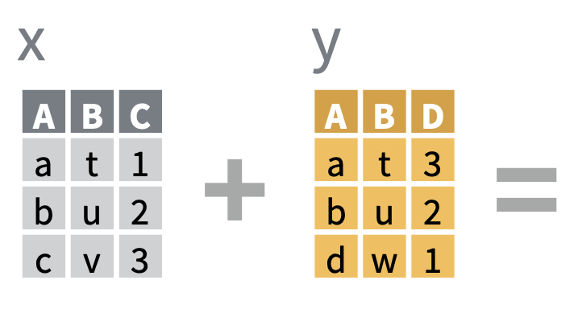

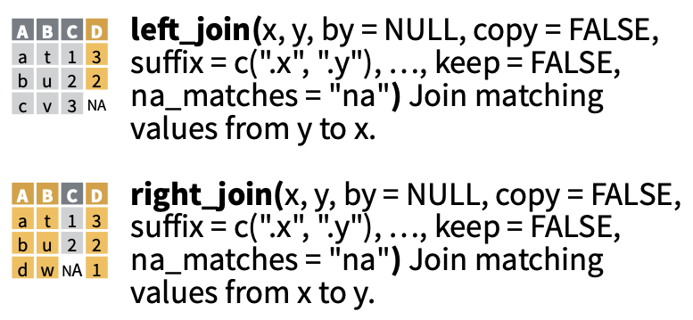

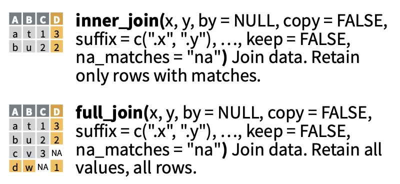

Fuente: [dplyr cheatsheet](https://rstudio.github.io/cheatsheets/data-transformation.pdf)

## ¿Qué hace `left_join()`?

`left_join()` junta dos data frames basándose en un **identificador común**: una columna clave que está en las dos tablas (aquí, `site_id`).

En nuestro ejemplo, con `data_trial` y `sites`:

- Mantiene **todas las filas** de la tabla izquierda (`data_trial`)
- Añade las columnas de la tabla derecha (`sites`) donde coincide la columna clave
- Si no hay coincidencia, rellena con `NA`

## `left_join()` — mantener todo de la izquierda

Unir **todos** los pacientes con los datos de las clínicas por `site_id`

```r
datos_con_clinica <- left_join(data_trial, sites, by = "site_id")
head(datos_con_clinica)
```

```
# A tibble: 6 x 20
  patient_id site_id group sex      age n_sessions anxiety_pre anxiety_post
       <dbl> <chr>   <chr> <chr>  <dbl>      <dbl>       <dbl>        <dbl>
1          1 site_01 CBT   male      42         11        20           16.6
2          2 site_01 CBT   male      23         13        17.7         12.3
3          3 site_02 CBT   female    56         15        15.5         11
4          4 site_01 CBT   male      39         15        15.9         11.4
5          5 site_02 CBT   male      36         10        12.7          9.1
6          6 site_03 CBT   female    27         17        14.3          8.4
# i 12 more variables: depression_pre <dbl>, depression_post <dbl>,
#   wellbeing_pre <dbl>, wellbeing_post <dbl>, ucla_pre <dbl>, ucla_post <dbl>,
#   rosenberg_pre <dbl>, rosenberg_post <dbl>, city <chr>, region <chr>,
#   director <chr>, capacity <dbl>
```

## Ejercicio 9 — unir, clasificar y comparar

Tiempo: 20 minutos

1. Carga los datos de seguimiento: `data_followup <- read_csv(here("data", "raw_data", "data_clinical_trial_followup.csv"))`
2. Haz un `left_join()` de `data_trial` con `data_followup` por `patient_id`
3. Clasifica la gravedad de ansiedad en **pre**, **post** y **followup** con `case_when()` (GAD-7: ≤4 mínima, ≤9 leve, ≤14 moderada, resto grave)
4. Cuenta el número de pacientes en cada categoría de gravedad para cada momento (`count()`)
5. Crea columnas de **mejora** (`anxiety_pre - anxiety_post`) y **mantenimiento** (`anxiety_post - anxiety_followup`) con `mutate()`
6. Guarda el resultado en `datos_clasificados`

## Resumen del bloque 2

Ordenar filas

`arrange()``desc()`

Crear y transformar variables

`mutate()``round()`

Condicionales

`if_else()``case_when()``.default =``count()`

Combinar tablas

`bind_rows()``bind_cols()`

Joins

`left_join()``by = "site_id"`